# Exercise 1: Multiple regression

# Installing Lavaan

The lavaan package is available on CRAN.Therefore, to install lavaan, simply start up R (studio), and type in the R console:

```r
if (!require("lavaan")) install.packages("lavaan", dependencies = TRUE)
```

Install this package first (once). You can check if the installation was successful by typing:

```r
library(lavaan)
```

A startup message will be displayed showing the version number (always report this in your papers), and a reminder that this is free software. If you see this message, you are ready to start.

# Data

## Read in data

```r
data_regr <- read.table("popular_regr.txt", header = T)
```

If using data without header, then:

```r
colnames(data_regr) <- c("respnr", "Dutch", "gender", "sw", "covert", "overt")
```

## Denote missing values

-99 and -999 is missing, so set this to NA:

```r
data_regr[sapply(data_regr, function(x) as.character(x) %in% c("-99", "-999") )] <- NA
```

If you forget to tell R that -99 and -999 are used to denote missing data, these values will be treated as being observed.

## Descriptive statistics

Variables of interest: sw, covert, and overt

```r
colnames(data_regr)
```

```
## [1] "respnr" "Dutch"  "gender" "sw"     "covert" "overt"
```

So, columns 4 to 6.

The psych package can be used to obtain some extended summary statistics.

```r
if (!require("psych")) install.packages("psych", dependencies = TRUE)
library(psych)
```

Descriptives like mean, median, min, and max:

```r
describe(data_regr[, 4:6])
```

```
##        vars    n mean   sd median trimmed  mad  min  max range skew kurtosis
## sw        1 1346 3.63 0.68   3.64    3.62 0.67 1.45 5.91  4.45 0.13     0.10
## covert    2 1343 1.94 0.60   2.00    1.92 0.74 1.00 3.75  2.75 0.29    -0.40
## overt     3 1344 1.32 0.37   1.25    1.26 0.37 1.00 3.12  2.12 1.60     2.96
##          se
## sw     0.02
## covert 0.02
## overt  0.01
```

## Correlations

Correlations for the three variables of interest, incl correlation significance test can be obtained using the rcorr function from the Hmisc package.

```r
if (!require("Hmisc")) install.packages("Hmisc", dependencies = TRUE)
library(Hmisc)
```

```r
res <- rcorr(as.matrix(data_regr[, 4:6])) # rcorr() accepts matrices only
```

Correlation matrix (rounded to 3 decimals):

```r
round(res$r, 3)
```

```
##            sw covert  overt
## sw      1.000 -0.510 -0.334
## covert -0.510  1.000  0.386
## overt  -0.334  0.386  1.000
```

P-values (rounded to 3 decimals):

```r
round(res$P, 3)
```

```
##        sw covert overt
## sw     NA      0     0
## covert  0     NA     0
## overt   0      0    NA
```

Sample size:

```r
res$n
```

```
##          sw covert overt
## sw     1346   1343  1344
## covert 1343   1343  1343
## overt  1344   1343  1344
```

Possible conclusions:

- covert and overt are related to sw, so makes sense (in combination with theory) to use them as predictors.
- Their relationship is negative, so an decrease in (c)overt relates to an increase in sw.
- covert and overt are also related (positively) to each other, but not that much (in absolute sense) that we should worry about multicolinearity.

# Specify the regression model

Now, let us run a multiple regression model predicting levels of socially desirable answering patterns of adolescents (sw) using the predictors overt (overt) and covert antisocial behaviour (covert).

To run a multiple regression with lavaan, you first specify the model, then fit the model and finally acquire the summary. To fit the model we use the lavaan() function, which needs a model= and a data= input.

The model is specified as follows: `dependent ~ predictor1 + predictor2 + etc`

The ~ is like the = in a regression equation.

Before the ~, one states the dependent variable.

After the ~, one states the predictors, each separated by the + sign.

Additionally, one needs to specify that the error (of the dependent variable) has a variance: `dependent ~~ dependent`

If needed (as is the case here), one can specify to include an intercept: `dependent ~ 1`

Our regression model is specified as follows:

```r
model.regression <- '
  sw ~ overt + covert # regression
  sw ~~ sw            # residual variance
  sw ~ 1              # intercept
'
```

# Fit the regression model

```r
fit_regr <- lavaan(model = model.regression, data = data_regr)
```

Note: Instead of specifying intercepts and means in the model, one can include `meanstructure=TRUE` in the lavaan function.

# Output

```r
summary(fit_regr, fit.measures = TRUE, ci = TRUE, rsquare = TRUE)
```

```
## lavaan 0.6-11 ended normally after 15 iterations
##
##   Estimator                                         ML
##   Optimization method                           NLMINB
##   Number of model parameters                         4
##
##                                                   Used       Total
##   Number of observations                          1343        1491
##
## Model Test User Model:
##
##   Test statistic                                 0.000
##   Degrees of freedom                                 0
##
## Model Test Baseline Model:
##
##   Test statistic                               444.065
##   Degrees of freedom                                 2
##   P-value                                        0.000
##
## User Model versus Baseline Model:
##
##   Comparative Fit Index (CFI)                    1.000
##   Tucker-Lewis Index (TLI)                       1.000
##
## Loglikelihood and Information Criteria:
##
##   Loglikelihood user model (H0)              -1159.083
##   Loglikelihood unrestricted model (H1)      -1159.083
##
##   Akaike (AIC)                                2326.167
##   Bayesian (BIC)                              2346.978
##   Sample-size adjusted Bayesian (BIC)         2334.271
##
## Root Mean Square Error of Approximation:
##
##   RMSEA                                          0.000
##   90 Percent confidence interval - lower         0.000
##   90 Percent confidence interval - upper         0.000
##   P-value RMSEA <= 0.05                             NA
```

[output cut: 13 more lines]

```
##   sw ~
##     overt            -0.292    0.046   -6.381    0.000   -0.381   -0.202
##     covert           -0.507    0.028  -17.866    0.000   -0.563   -0.451
##
## Intercepts:
##                    Estimate  Std.Err  z-value  P(>|z|) ci.lower ci.upper
##    .sw                4.997    0.066   75.581    0.000    4.867    5.126
##
## Variances:
##                    Estimate  Std.Err  z-value  P(>|z|) ci.lower ci.upper
##    .sw                0.329    0.013   25.913    0.000    0.304    0.354
##
## R-Square:
##                    Estimate
##     sw                0.282
```

Can add `standardized=TRUE` to obtain standardized estimates as well.

- Note that the residual variances are denoted by stating a “.” before the variable name. Here: `.sw`
- Note that the intercepts are denoted by stating a “.” before the variable name. Here: `.sw`

# Parameter estimates

Unstandardized regression parameters

```r
coef(fit_regr)
```

```
##  sw~overt sw~covert    sw~~sw      sw~1
##    -0.292    -0.507     0.329     4.997
```

All unstandardized parameters - with extra information

```r
parameterEstimates(fit_regr)
```

```
##      lhs op    rhs    est    se       z pvalue ci.lower ci.upper
## 1     sw  ~  overt -0.292 0.046  -6.381      0   -0.381   -0.202
## 2     sw  ~ covert -0.507 0.028 -17.866      0   -0.563   -0.451
## 3     sw ~~     sw  0.329 0.013  25.913      0    0.304    0.354
## 4     sw ~1         4.997 0.066  75.581      0    4.867    5.126
## 5  overt ~~  overt  0.138 0.000      NA     NA    0.138    0.138
## 6  overt ~~ covert  0.086 0.000      NA     NA    0.086    0.086
## 7 covert ~~ covert  0.357 0.000      NA     NA    0.357    0.357
## 8  overt ~1         1.325 0.000      NA     NA    1.325    1.325
## 9 covert ~1         1.941 0.000      NA     NA    1.941    1.941
```

All standardized parameters - with extra information

```r
standardizedSolution(fit_regr)
```

```
##      lhs op    rhs est.std    se       z pvalue ci.lower ci.upper
## 1     sw  ~  overt  -0.160 0.025  -6.478      0   -0.208   -0.112
## 2     sw  ~ covert  -0.448 0.022 -20.388      0   -0.491   -0.405
## 3     sw ~~     sw   0.718 0.019  37.255      0    0.681    0.756
## 4     sw ~1          7.384 0.111  66.758      0    7.167    7.601
## 5  overt ~~  overt   1.000 0.000      NA     NA    1.000    1.000
## 6  overt ~~ covert   0.386 0.000      NA     NA    0.386    0.386
## 7 covert ~~ covert   1.000 0.000      NA     NA    1.000    1.000
## 8  overt ~1          3.568 0.000      NA     NA    3.568    3.568
## 9 covert ~1          3.247 0.000      NA     NA    3.247    3.247
```

Note that now you also obtain the confidence interval of the standardized estimates.

# Fit measures

Many model fit measures

```r
fitMeasures(fit_regr)
```

```
##                npar                fmin               chisq                  df
##               4.000               0.000               0.000               0.000
##              pvalue      baseline.chisq         baseline.df     baseline.pvalue
##                  NA             444.065               2.000               0.000
##                 cfi                 tli                nnfi                 rfi
##               1.000               1.000               1.000               1.000
##                 nfi                pnfi                 ifi                 rni
##               1.000               0.000               1.000               1.000
##                logl   unrestricted.logl                 aic                 bic
##           -1159.083           -1159.083            2326.167            2346.978
##              ntotal                bic2               rmsea      rmsea.ci.lower
##            1343.000            2334.271               0.000               0.000
##      rmsea.ci.upper        rmsea.pvalue                 rmr          rmr_nomean
##               0.000                  NA               0.000               0.000
##                srmr        srmr_bentler srmr_bentler_nomean                crmr
##               0.000               0.000               0.000               0.000
##         crmr_nomean          srmr_mplus   srmr_mplus_nomean               cn_05
##               0.000               0.000               0.000                  NA
##               cn_01                 gfi                agfi                pgfi
##                  NA               1.000               1.000               0.000
##                 mfi                ecvi
##               1.000               0.006
```

Ask for specific model fit measures

```r
fitMeasures(fit_regr, c("cfi", "tli", "rmsea","srmr"))
```

```
##   cfi   tli rmsea  srmr
##     1     1     0     0
```

R-square (for sw)

```r
inspect(fit_regr, 'r2')
```

```
##    sw
## 0.282
```

# Technical output

Comparable to TECH1 in Mplus. More details about this in exercise 3.

```r
lavInspect(fit_regr)
```

```
## $lambda
##        sw overt covert
## sw      0     0      0
## overt   0     0      0
## covert  0     0      0
##
## $theta
##        sw overt covert
## sw     0
## overt  0  0
## covert 0  0     0
##
## $psi
##        sw overt covert
## sw     3
## overt  0  0
## covert 0  0     0
##
## $beta
##        sw overt covert
## sw      0     1      2
## overt   0     0      0
## covert  0     0      0
##
## $nu
##        intrcp
## sw          0
## overt       0
## covert      0
##
## $alpha
##        intrcp
## sw          4
## overt       0
## covert      0
```

# Possible conclusions:

- The regression equation looks as follows:
  $$sw = 4.997 - 0.292 * overt - 0.507 * covert +
  error$$
- The average sw (levels of socially desirable answering patterns of adolescents) when covert and overt antisocial behaviour are 0 is 4.997;

  When overt goes up with one point, then sw goes down with 0.292 points;

  When covert goes up with one point, then sw goes down with 0.507 points.

  When you are the expert (and look at the scale of the data), you can judge whether these are relevant effects.
- The p-values and confidence intervals indicate that both effects significantly differ from zero. Thus, both variables are (statistically) meaningful predictors.
- The two predictors explain 0.282*100=28.2 percent of sw.
- When looking at the absolute values of the standardized effects, covert is a more important predictor than overt: |-0.448| > |-0.160|.

# Plot

With lavaanPlot:

```r
if (!require("lavaanPlot")) install.packages("lavaanPlot")
library(lavaanPlot)
lavaanPlot(model = fit_regr,
           node_options = list(shape = "box", fontname = "Helvetica"),
           edge_options = list(color = "grey"), coefs = T, stand = T, covs = T)
```

[interactive chart not shown]

Alternatively, with tidySEM:

```r
if (!require("tidySEM")) install.packages("tidySEM")
```

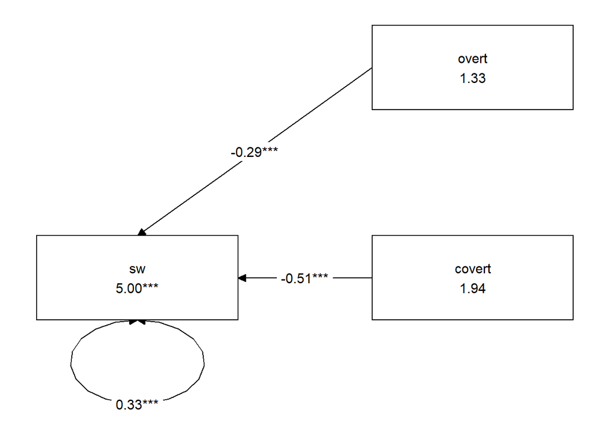

```r
library(tidySEM)
graph_sem(fit_regr)
```

# Handling missing data Note that in the above listwise deletion is used.From the output, one can see that the total sample size used for the analyses is n=1343, while the total number of observations is 1491.

lavaan used listwise deletion and deleted 148 cases: - 145 cases because of missingness on the dependent variables and - 3 cases because of missingness on the predictors.

The code to use FIML is:

```r
model.regression <- '
  sw ~ overt + covert # regression
  sw ~~ sw            # residual variance
  sw ~ 1              # intercept
  #
  # (co)variances predictors
  overt + covert ~~ overt
  covert ~~ covert
'
fit_regr <- lavaan(model = model.regression, data = data_regr,
                       missing='fiml', fixed.x=F) # Specify FIML
```

Afterwards one can do the same as above. E.g., to get the output:

```r
summary(fit_regr, fit.measures = TRUE, ci = TRUE, rsquare = TRUE)
```

```
## lavaan 0.6-11 ended normally after 36 iterations
##
##   Estimator                                         ML
##   Optimization method                           NLMINB
##   Number of model parameters                         7
##
##                                                   Used       Total
##   Number of observations                          1346        1491
##   Number of missing patterns                         3
##
## Model Test User Model:
##
##   Test statistic                              3874.022
##   Degrees of freedom                                 2
##   P-value (Chi-square)                           0.000
##
## Model Test Baseline Model:
##
##   Test statistic                               661.452
##   Degrees of freedom                                 3
##   P-value                                        0.000
##
## User Model versus Baseline Model:
##
##   Comparative Fit Index (CFI)                    0.000
##   Tucker-Lewis Index (TLI)                      -7.821
##
## Loglikelihood and Information Criteria:
##
##   Loglikelihood user model (H0)              -4781.689
##   Loglikelihood unrestricted model (H1)      -2844.678
##
##   Akaike (AIC)                                9577.378
##   Bayesian (BIC)                              9613.812
##   Sample-size adjusted Bayesian (BIC)         9591.576
##
## Root Mean Square Error of Approximation:
##
##   RMSEA                                          1.199
##   90 Percent confidence interval - lower         1.168
```

[output cut: 24 more lines]

```
## Intercepts:
##                    Estimate  Std.Err  z-value  P(>|z|) ci.lower ci.upper
##    .sw                4.993    0.066   75.456    0.000    4.864    5.123
##     overt             0.000                               0.000    0.000
##     covert            0.000                               0.000    0.000
##
## Variances:
##                    Estimate  Std.Err  z-value  P(>|z|) ci.lower ci.upper
##    .sw                0.329    0.013   25.918    0.000    0.304    0.354
##     overt             1.892    0.073   25.940    0.000    1.749    2.035
##     covert            4.118    0.159   25.940    0.000    3.807    4.429
##
## R-Square:
##                    Estimate
##     sw                0.858
```

# lavaan notation

| formula type | operator | mnemonic |
| --- | --- | --- |
| regression | ~ | is regressed on |
| (residual) (co)variance | ~~ | is correlated with |
| intercept | ~ 1 | intercept |
| latent variable definition | =~ | is measured by (Used in other days of the course) |

## General lavaan specification

### regressions

y1 + y2 ~ f1 + f2 + x1 + x2

f1 ~ f2 + f3

f2 ~ f3 + x1 + x2

### latent variable definitions

f1 =~ y1 + y2 + y3

f2 =~ y4 + y5 + y6

f3 =~ y7 + y8 + y9 + y10

### variances and covariances

y1 ~~ y1

y ~~ y2

f1 ~~ f2

### intercepts

y1 ~ 1

f1 ~ 1